# Scientific Programming with Python

## Assignment 6: Galileo's Horizontal Ball Drop

### Helena Heyen 9031786

Link to the Assignment

This assignment is about the Ball Drop Experiment conducted by Galileo in 1608, where a ball was released from different heights on an incline and its horizontal distance traveled was measured in units of "Galileo Points".  
The objective is to compare the experiment data to data computed by two equations for calculating the distance, one obtained from Galileo's writings, the other an adjusted formula to describe the same experiment. The solution should be developed using data interpolation/extrapolation with SciPy and presented using Matplotlib.

```python
import math
import matplotlib.pyplot as plt
from scipy.interpolate import interp1d
```

#### Task 1: Create user-defined functions for following equations:

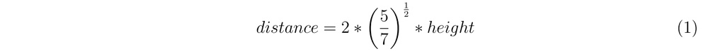

```python
def galileo_distance_1 (height):
    return 2 * (5/7)**0.5 * height
```

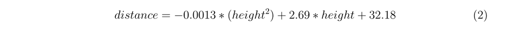

```python
def galileo_distance_2 (height):
    return -0.0013 * (height**2) + 2.69 * height + 32.18
```

#### Task 2: Compute the Root-Mean-Square-Error of the experiment values versus calculated values by equations 1 and 2:

Fist, I provide a method for calculating the RMSE according to the formula given in the assignment.

```python
def rmse_calculator (calculated, experiment):
    """
    Calculates the Root Mean Squared Error (RMSE) between calculated values and experimental values.

    Parameters:
        calculated: List of calculated values.
        experiment: List of experimental values.

    Returns:
        float: Root Mean Squared Error (RMSE) value.
    """
    if len(calculated) == len(experiment):
        mean_squared_error = sum([(calculated - experiment)**2
                                  for calculated, experiment in zip(calculated, experiment)]) / len(calculated)
    return math.sqrt(mean_squared_error)
```

Using the heights from the experiment the corresponding distances are calculated using Equations 1 and 2.  
Both the calculated values and experimental values are then passed to the previously defined method that calculates the Root Mean Squared Error (RMSE). This RMSE value represents the average distance between the two groups of values [1], both measured in Galileo Points.

```python
experiment_height = [300, 600, 800, 828, 1000]
experiment_distance = [800, 1172, 1328, 1340, 1500]

calculated_distance_1 = [galileo_distance_1(height) for height in experiment_height]
calculated_distance_2 = [galileo_distance_2(height) for height in experiment_height]

rmse_1 = rmse_calculator(calculated_distance_1, experiment_distance)
rmse_2 = rmse_calculator(calculated_distance_2, experiment_distance)

print ("Galileo's measurements vs. Equation 1:", rmse_1)
print ("Galileo's measurements vs. Equation 2:", rmse_2)
```

```
Galileo's measurements vs. Equation 1: 173.8129935702819
Galileo's measurements vs. Equation 2: 52.0236722745329
```

The results show that Equation 2 exhibits a smaller deviation from the experimental values compared to Equation 1. This suggests that Equation 2 provides a more accurate representation of Galileo's experiment, indicating a closer alignment between the calculated values and the experimental measurements.

#### Task 3: Utilize the 'interp1d' function from SciPy to interpolate and extrapolate new data based on the experiment values. Generate data using different kinds of extrapolations: 'linear', 'quadratic', 'cubic', 'nearest', 'previous', and 'next'.

```python
f_linear = interp1d(experiment_height, experiment_distance, kind='linear', bounds_error=False)
f_quadratic = interp1d(experiment_height, experiment_distance, kind='quadratic', bounds_error=False)
f_cubic = interp1d(experiment_height, experiment_distance, kind='cubic', bounds_error=False)
f_nearest = interp1d(experiment_height, experiment_distance, kind='nearest', bounds_error=False)
f_previous = interp1d(experiment_height, experiment_distance, kind='previous', bounds_error=False)
f_next = interp1d(experiment_height, experiment_distance, kind='next', bounds_error=False)
```

#### Use an input height range from 0 to 1000 "points" for the 'x' parameter to obtain both interpolated and extrapolated data.

```python
height_range = list(range(0, 1001))
y_linear = [f_linear(x) for x in height_range]
y_quadratic = [f_quadratic(x) for x in height_range]
y_cubic = [f_cubic(x) for x in height_range]
y_nearest = [f_nearest(x) for x in height_range]
y_previous = [f_previous(x) for x in height_range]
y_next = [f_next(x) for x in height_range]
```

#### Task 4: Plot Galileo's experimentally measured data alongside the data from Equations 1 and 2 as well as the new data generated in Task 3.

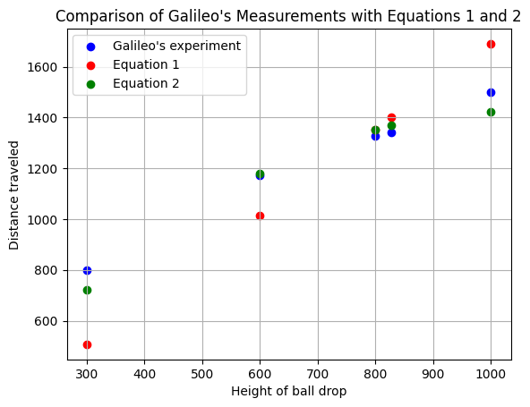

```python
distance_plot, ax = plt.subplots()
ax.scatter(experiment_height, experiment_distance, label="Galileo's experiment", c='blue')
ax.scatter(experiment_height, calculated_distance_1, label='Equation 1', c='red')
ax.scatter(experiment_height, calculated_distance_2, label='Equation 2', c='green')
ax.legend()
plt.xlabel('Height of ball drop')
plt.ylabel('Distance traveled')
plt.title("Comparison of Galileo's Measurements with Equations 1 and 2")
plt.grid()
plt.show()
```

The plot clearly illustrates that Equation 2 exhibits a closer alignment with the experimental values.

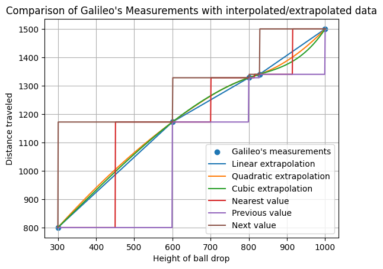

```python
interpolation_plot, ax = plt.subplots()
ax.scatter(experiment_height, experiment_distance, label="Galileo's measurements")
ax.plot(height_range, y_linear, label='Linear extrapolation')
ax.plot(height_range, y_quadratic, label='Quadratic extrapolation')
ax.plot(height_range, y_cubic, label='Cubic extrapolation')
ax.plot(height_range, y_nearest, label='Nearest value')
ax.plot(height_range, y_previous, label='Previous value')
ax.plot(height_range, y_next, label='Next value')
ax.legend()
plt.xlabel('Height of ball drop')
plt.ylabel('Distance traveled')
plt.title("Comparison of Galileo's Measurements with interpolated/extrapolated data")
plt.grid()
plt.show()
```

### References:

[1] https://statisticsbyjim.com/regression/root-mean-square-error-rmse/  
[2] https://docs.scipy.org/doc/scipy/reference/generated/scipy.interpolate.interp1d.html